# Array Creation and Properties

this notebook is based on the SciPy NumPy tutorial

```python
import numpy as np
```

```python
a = np.arange(15).reshape(3,5)

print a
```

```
[[ 0  1  2  3  4]
 [ 5  6  7  8  9]
 [10 11 12 13 14]]
```

```python
print a.ndim
print a.shape
print a.size
print a.dtype
print a.itemsize
print type(a)
```

```
2
(3, 5)
15
int64
8
<type 'numpy.ndarray'>
```

we can create an array from a list

```python
b = np.array( [1.0, 2.0, 3.0, 4.0] )
print b
print b.dtype
```

```
[ 1.  2.  3.  4.]
float64
```

we can create a multi-dimensional array of a specified size initialized all to 0 easily. There is also an analogous ones() and empty() array routine.

```python
c = np.zeros( (10,7), dtype=np.float64)
print c
```

```
[[ 0.  0.  0.  0.  0.  0.  0.]
 [ 0.  0.  0.  0.  0.  0.  0.]
 [ 0.  0.  0.  0.  0.  0.  0.]
 [ 0.  0.  0.  0.  0.  0.  0.]
 [ 0.  0.  0.  0.  0.  0.  0.]
 [ 0.  0.  0.  0.  0.  0.  0.]
 [ 0.  0.  0.  0.  0.  0.  0.]
 [ 0.  0.  0.  0.  0.  0.  0.]
 [ 0.  0.  0.  0.  0.  0.  0.]
 [ 0.  0.  0.  0.  0.  0.  0.]]
```

linspace (and logspace) create arrays with evenly space (in log) numbers. For logspace, you specify the start and ending powers (base**start to base**stop)

```python
d = np.linspace(0, 1, 10, endpoint=False)
print d
```

```
[ 0.   0.1  0.2  0.3  0.4  0.5  0.6  0.7  0.8  0.9]
```

```python
e = np.logspace(-1, 2, 15, endpoint=False, base=10)
print e
```

```
[  0.1          0.15848932   0.25118864   0.39810717   0.63095734   1.
   1.58489319   2.51188643   3.98107171   6.30957344  10.          15.84893192
  25.11886432  39.81071706  63.09573445]
```

we can also initialize an array based on a function

```python
f = np.fromfunction(lambda i, j: i + j, (3, 3), dtype=int)
f
```

```
array([[0, 1, 2],
       [1, 2, 3],
       [2, 3, 4]])
```

```python
def myFun(x,y):
    return 10*x+y

g = np.fromfunction(myFun, (5,4), dtype=int)
g
```

```
array([[ 0,  1,  2,  3],
       [10, 11, 12, 13],
       [20, 21, 22, 23],
       [30, 31, 32, 33],
       [40, 41, 42, 43]])
```

# Array Operations

most operations will work on an entire array at once

```python
a = np.arange(12).reshape(3,4)
print a
```

```
[[ 0  1  2  3]
 [ 4  5  6  7]
 [ 8  9 10 11]]
```

```python
print a.sum(axis=0)
```

```
[12 15 18 21]
```

```python
print a.sum()
```

```
66
```

```python
print a.min(), a.max()
```

```
0 11
```

### universal functions

```python
b = a*np.pi/12.0
print b
```

```
[[ 0.          0.26179939  0.52359878  0.78539816]
 [ 1.04719755  1.30899694  1.57079633  1.83259571]
 [ 2.0943951   2.35619449  2.61799388  2.87979327]]
```

```python
c = np.cos(b)
print c
```

```
[[  1.00000000e+00   9.65925826e-01   8.66025404e-01   7.07106781e-01]
 [  5.00000000e-01   2.58819045e-01   6.12323400e-17  -2.58819045e-01]
 [ -5.00000000e-01  -7.07106781e-01  -8.66025404e-01  -9.65925826e-01]]
```

```python
d = b + c
```

```python
print d
```

```
[[ 1.          1.22772521  1.38962418  1.49250494]
 [ 1.54719755  1.56781598  1.57079633  1.57377667]
 [ 1.5943951   1.64908771  1.75196847  1.91386744]]
```

# Slicing

slicing works very similarly to how we saw with strings

```python
a = np.fromfunction(myFun, (5,4),dtype=int)
print a
print " "

print a[1,1]
print " "

print a[0:2,0:2]
print " "

print a[:,1]
print " "

print a.flatten()
```

```
[[ 0  1  2  3]
 [10 11 12 13]
 [20 21 22 23]
 [30 31 32 33]
 [40 41 42 43]]

11

[[ 0  1]
 [10 11]]

[ 1 11 21 31 41]

[ 0  1  2  3 10 11 12 13 20 21 22 23 30 31 32 33 40 41 42 43]
```

we can also iterate -- this is done over the first axis

```python
for row in a:
    print row
```

```
[0 1 2 3]
[10 11 12 13]
[20 21 22 23]
[30 31 32 33]
[40 41 42 43]
```

or element by element

```python
for e in a.flat:
    print e
```

```
0
1
2
3
10
11
12
13
20
21
22
23
30
31
32
33
40
41
42
43
```

# Copying Arrays

simply using "=" does not make a copy, but much like with lists, you will just have multiple names pointing to the same ndarray object

```python
a = np.arange(10)
print a
```

```
[0 1 2 3 4 5 6 7 8 9]
```

```python
b = a
b is a
```

```
True
```

```python
b.shape = (2,5)
print b
a.shape
```

```
[[0 1 2 3 4]
 [5 6 7 8 9]]
```

```
(2, 5)
```

a shallow copy creates a new view into the array -- the data is the same, but the array properties can be different

```python
a = np.arange(12)
c = a[:]
a.shape = (3,4)

print a
print c
```

```
[[ 0  1  2  3]
 [ 4  5  6  7]
 [ 8  9 10 11]]
[ 0  1  2  3  4  5  6  7  8  9 10 11]
```

```python
c[1] = -1
print a
```

```
[[ 0 -1  2  3]
 [ 4  5  6  7]
 [ 8  9 10 11]]
```

```python
print c is a
print c.base is a
print c.flags.owndata
```

```
False
True
False
```

to make a copy of the data of the array that you can deal with independently of the original, you need a deep copy

```python
d = a.copy()
d[:,:] = 0.0

print a
print d
```

```
[[ 0 -1  2  3]
 [ 4  5  6  7]
 [ 8  9 10 11]]
[[0 0 0 0]
 [0 0 0 0]
 [0 0 0 0]]
```

# Boolean Indexing

```python
a = np.arange(12).reshape(3,4)
```

```python
b = a > 4
b
```

```
array([[False, False, False, False],
       [False,  True,  True,  True],
       [ True,  True,  True,  True]], dtype=bool)
```

```python
a[b] = 0
a
```

```
array([[0, 1, 2, 3],
       [4, 0, 0, 0],
       [0, 0, 0, 0]])
```

```python
a[a == 0] = -1
a
```

```
array([[-1,  1,  2,  3],
       [ 4, -1, -1, -1],
       [-1, -1, -1, -1]])
```

# Avoiding Loops

### start by initialize coordinate arrays and a Gaussian function

```python
# create 1-d x and y arrays -- we define the coordinate values such that
# they are centered in the bin
N = 32
xmin = ymin = 0.0
xmax = ymax = 1.0

x = (np.arange(N)+0.5)*(xmax - xmin)/N + xmin
y = x.copy()

x2d = np.repeat(x, N)
x2d.shape = (N, N)

y2d = np.repeat(y, N)
y2d.shape = (N, N)
y2d = np.transpose(y2d)

print x2d
print y2d
```

```
[[ 0.015625  0.015625  0.015625 ...,  0.015625  0.015625  0.015625]
 [ 0.046875  0.046875  0.046875 ...,  0.046875  0.046875  0.046875]
 [ 0.078125  0.078125  0.078125 ...,  0.078125  0.078125  0.078125]
 ...,
 [ 0.921875  0.921875  0.921875 ...,  0.921875  0.921875  0.921875]
 [ 0.953125  0.953125  0.953125 ...,  0.953125  0.953125  0.953125]
 [ 0.984375  0.984375  0.984375 ...,  0.984375  0.984375  0.984375]]
[[ 0.015625  0.046875  0.078125 ...,  0.921875  0.953125  0.984375]
 [ 0.015625  0.046875  0.078125 ...,  0.921875  0.953125  0.984375]
 [ 0.015625  0.046875  0.078125 ...,  0.921875  0.953125  0.984375]
 ...,
 [ 0.015625  0.046875  0.078125 ...,  0.921875  0.953125  0.984375]
 [ 0.015625  0.046875  0.078125 ...,  0.921875  0.953125  0.984375]
 [ 0.015625  0.046875  0.078125 ...,  0.921875  0.953125  0.984375]]
```

Here we initialize an array with a Gaussian

```python
g = np.exp(-((x2d-0.5)**2 + (y2d-0.5)**2)/0.2**2)
print g
```

```
[[  8.04100059e-06   1.67261841e-05   3.31343050e-05 ...,   3.31343050e-05
    1.67261841e-05   8.04100059e-06]
 [  1.67261841e-05   3.47923410e-05   6.89230749e-05 ...,   6.89230749e-05
    3.47923410e-05   1.67261841e-05]
 [  3.31343050e-05   6.89230749e-05   1.36535517e-04 ...,   1.36535517e-04
    6.89230749e-05   3.31343050e-05]
 ...,
 [  3.31343050e-05   6.89230749e-05   1.36535517e-04 ...,   1.36535517e-04
    6.89230749e-05   3.31343050e-05]
 [  1.67261841e-05   3.47923410e-05   6.89230749e-05 ...,   6.89230749e-05
    3.47923410e-05   1.67261841e-05]
 [  8.04100059e-06   1.67261841e-05   3.31343050e-05 ...,   3.31343050e-05
    1.67261841e-05   8.04100059e-06]]
```

```python
%pylab inline
```

```
Welcome to pylab, a matplotlib-based Python environment [backend: module://IPython.zmq.pylab.backend_inline].
For more information, type 'help(pylab)'.
```

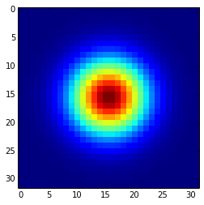

```python
imshow(g, interpolation="nearest")
```

### Numerical differencing on NumPy arrays

Now we want to construct

$\nabla^2 g \cdot \Delta x^2$

using differences between adjacent cells (think about the Calculus definition of a derivative)

$\nabla^2 g \cdot \Delta x^2 \sim {g_{i-1,j} + g_{i+1,j} - 2 g_{i,j}} + {g_{i,j-1} + g_{i,j+1} - 2 g_{i,j}}$

We'll do this two different ways---the first is with explicit loops and the second is using NumPy slice notation

```python
d2g = np.zeros((N,N), dtype=np.float64)
```

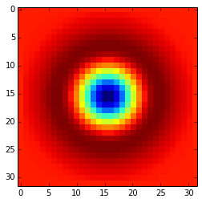

```python
i = 1
while i < N-1:
    j = 1
    while j < N-1:
        d2g[i,j] = g[i+1,j] + g[i-1,j] + g[i,j+1] + g[i,j-1] - 4*g[i,j]
        j += 1
    i += 1

imshow(d2g, interpolation="nearest")
```

```python
d2gb = np.zeros((N,N), dtype=np.float64)
print d2gb.shape
```

```
(32, 32)
```

```python
d2gb[1:N-1,1:N-1] = g[2:N,1:N-1] + g[0:N-2,1:N-1] + g[1:N-1,2:N] + g[1:N-1,0:N-2] - 4*g[1:N-1,1:N-1]
```

```python
print np.max(d2g - d2gb)
```

```
0.0
```

### let's take this further, and try to radially bin the data

```python
rmin = 0
rmax = np.sqrt(xmax**2 + ymax**2)

nbins = np.int(np.sqrt(N**2 + N**2))
```

```python
# bins will hold the edges, so there is one more value than actual bin
# bin_centers holds the center value of the bin
bins = np.linspace(rmin, rmax, nbins+1)
bin_centers = 0.5*(bins[1:] + bins[:-1])
```

```python
# radius of each zone
xc = 0.5*(xmin + xmax)
yc = 0.5*(ymin + ymax)

r = np.sqrt( (x2d-xc)**2 + (y2d-yc)**2 )
```

```python
# bin the radii -- digitize returns an array with the same shape
# as the input array but with elements of the array specifying
# which bin that location belongs to (it gives i such that
# bins[i-1] <= x < bins[i]).  The value of whichbin will be 1
# if we are located in the bin defined by bins[0] to bins[1].
# This means that whichbin[0] will be 0.
whichbin = np.digitize(r.flat, bins)
```

```python
# bincount counts the number of occurrences of each non-negative
# integer value in whichbin.
ncount = np.bincount(whichbin)
```

```python
# now bin our function
g_bin = np.zeros(len(ncount)-1, dtype=np.float64)

n = 1
while (n < len(ncount)):
    # there is no whichbin == 0 -- that corresponds to the left edge
    g_bin[n-1] = np.sum(g.flat[whichbin==n])/np.sum(ncount[n])
    n += 1
```

```python
bin_centers = bin_centers[0:len(ncount)-1]
```

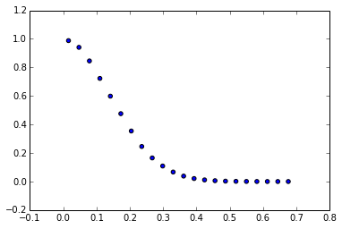

```python
scatter(bin_centers, g_bin)
```